# This notebook illustrate the linear regression using advertising dataset

### Load data, visualisation

```python
import pandas as pd
import numpy as np
```

```python
adv=pd.read_csv('Advertising.csv')
adv.head()
```

|  | Unnamed: 0 | TV | Radio | Newspaper | Sales |
| --- | --- | --- | --- | --- | --- |
| 0 | 1 | 230.1 | 37.8 | 69.2 | 22.1 |
| 1 | 2 | 44.5 | 39.3 | 45.1 | 10.4 |
| 2 | 3 | 17.2 | 45.9 | 69.3 | 9.3 |
| 3 | 4 | 151.5 | 41.3 | 58.5 | 18.5 |
| 4 | 5 | 180.8 | 10.8 | 58.4 | 12.9 |

The reason for unnamed is that the first column is not named and should be used as index.

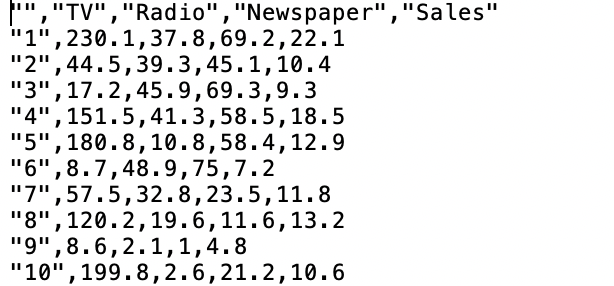

```python
from IPython.display import Image
Image("image/dataset.png")
```

```python
adv=pd.read_csv('Advertising.csv',index_col=0)
adv.head()
```

|  | TV | Radio | Newspaper | Sales |
| --- | --- | --- | --- | --- |
| 1 | 230.1 | 37.8 | 69.2 | 22.1 |
| 2 | 44.5 | 39.3 | 45.1 | 10.4 |
| 3 | 17.2 | 45.9 | 69.3 | 9.3 |
| 4 | 151.5 | 41.3 | 58.5 | 18.5 |
| 5 | 180.8 | 10.8 | 58.4 | 12.9 |

Looking for correlation

```python
adv.corr()
```

|  | TV | Radio | Newspaper | Sales |
| --- | --- | --- | --- | --- |
| TV | 1.000000 | 0.054809 | 0.056648 | 0.782224 |
| Radio | 0.054809 | 1.000000 | 0.354104 | 0.576223 |
| Newspaper | 0.056648 | 0.354104 | 1.000000 | 0.228299 |
| Sales | 0.782224 | 0.576223 | 0.228299 | 1.000000 |

We can see that there are clear correlations between Sales and Radio/TV, but the correlation betweens Sales and Newspaper is not that obvious.

Moreover, there is clear relationship between Newspaper and Radio (0.354). This is called collinearitly.

Similar patterns can be observed in scatter plot.

```python
import matplotlib.pyplot as plt
from pandas.plotting import scatter_matrix
```

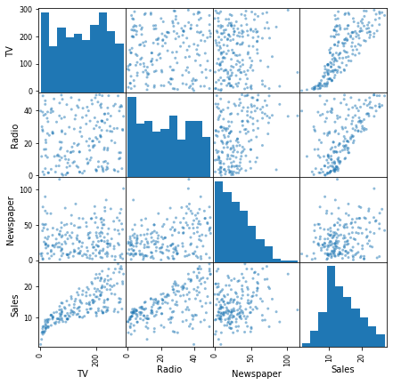

```python
scatter_matrix(adv,figsize=(7,7))
plt.show()
```

Split the training the test dataset. Here we use a simplest way: use the first 90% of the sample as the training, and the rest as the test.

```python
ndata=len(adv)
adv_train=adv.head(int(ndata*0.9)) ## int(x) get the integer part of x
adv_test=adv.tail(ndata - int(ndata*0.9))
```

## Simple Linear Regression

An alternative way to do linear regression is to use statsmodels.formula.api. The syntax here is similar to R. The advantage is that it provides a nice summary of statistical properties of the model.

```python
import statsmodels.formula.api as smf
results = smf.ols('Sales ~ TV', data=adv).fit()
print(results.summary())
```

```
                            OLS Regression Results
==============================================================================
Dep. Variable:                  Sales   R-squared:                       0.612
Model:                            OLS   Adj. R-squared:                  0.610
Method:                 Least Squares   F-statistic:                     312.1
Date:                Thu, 30 Jan 2020   Prob (F-statistic):           1.47e-42
Time:                        23:08:37   Log-Likelihood:                -519.05
No. Observations:                 200   AIC:                             1042.
Df Residuals:                     198   BIC:                             1049.
Df Model:                           1
Covariance Type:            nonrobust
==============================================================================
                 coef    std err          t      P>|t|      [0.025      0.975]
------------------------------------------------------------------------------
Intercept      7.0326      0.458     15.360      0.000       6.130       7.935
TV             0.0475      0.003     17.668      0.000       0.042       0.053
==============================================================================
Omnibus:                        0.531   Durbin-Watson:                   1.935
Prob(Omnibus):                  0.767   Jarque-Bera (JB):                0.669
Skew:                          -0.089   Prob(JB):                        0.716
Kurtosis:                       2.779   Cond. No.                         338.
==============================================================================

Warnings:
[1] Standard Errors assume that the covariance matrix of the errors is correctly specified.
```

The summary contains all the value of parameters, t-statistics, F-statistics. Also, it provides 95% confidence interval of each parameter. Let's verify whether the 95% interval is calculated correctly. From the textbook, we know: $$\beta_1 \in \left[\hat{\beta}_1 - t_{1-\alpha/2,n-2} \textrm{SE}(\hat{\beta}_1), \hat{\beta}_1 + t_{1-\alpha/2,n-2} \textrm{SE}(\hat{\beta}_1)\right]$$ and $$\beta_0 \in \left[\hat{\beta}_0 - t_{1-\alpha/2,n-2} \textrm{SE}(\hat{\beta}_0), \hat{\beta}_1 + t_{1-\alpha/2,n-2} \textrm{SE}(\hat{\beta}_0)\right]$$

```python
import scipy.stats as ss
```

Note that ss.t.isf function is the inverse of 1-F(x). Therefore, $\text{isf}(\alpha/2) = F^{-1}(1-\alpha/2)$

```python
tvalue= ss.t.isf(0.05/2,df=len(adv)-2)
tvalue
```

```
1.972017477833896
```

```python
(results.params['TV'] - tvalue* results.bse['TV'],results.params['TV'] + tvalue* results.bse['TV'])
```

```
(0.042230716032698824, 0.052842564833340704)
```

```python
(results.params['Intercept'] - tvalue* results.bse['Intercept'],results.params['Intercept'] + tvalue* results.bse['Intercept'])
```

```
(6.1297192688055375, 7.935467829449859)
```

## Multiple Linear Regression

```python
results_mul = smf.ols('Sales ~ TV + Radio + Newspaper ', data=adv).fit()
print(results_mul.summary())
```

```
                            OLS Regression Results
==============================================================================
Dep. Variable:                  Sales   R-squared:                       0.897
Model:                            OLS   Adj. R-squared:                  0.896
Method:                 Least Squares   F-statistic:                     570.3
Date:                Thu, 30 Jan 2020   Prob (F-statistic):           1.58e-96
Time:                        23:08:37   Log-Likelihood:                -386.18
No. Observations:                 200   AIC:                             780.4
Df Residuals:                     196   BIC:                             793.6
Df Model:                           3
Covariance Type:            nonrobust
==============================================================================
                 coef    std err          t      P>|t|      [0.025      0.975]
------------------------------------------------------------------------------
Intercept      2.9389      0.312      9.422      0.000       2.324       3.554
TV             0.0458      0.001     32.809      0.000       0.043       0.049
Radio          0.1885      0.009     21.893      0.000       0.172       0.206
Newspaper     -0.0010      0.006     -0.177      0.860      -0.013       0.011
==============================================================================
Omnibus:                       60.414   Durbin-Watson:                   2.084
Prob(Omnibus):                  0.000   Jarque-Bera (JB):              151.241
Skew:                          -1.327   Prob(JB):                     1.44e-33
Kurtosis:                       6.332   Cond. No.                         454.
==============================================================================

Warnings:
[1] Standard Errors assume that the covariance matrix of the errors is correctly specified.
```

We can also calculate $\hat{\sigma}$: $$\sigma \approx \hat{\sigma} = \textrm{RSE} = \sqrt{\textrm{RSS}/(n - m -1 )}$$

```python
results_mul.predict(adv) - adv['Sales']
```

```
1     -1.576026
2      1.937855
3      3.007671
4     -0.902170
5      0.288672
         ...
196   -2.229658
197   -1.534688
198   -0.014079
199   -1.732679
200    1.773196
Length: 200, dtype: float64
```

```python
RSS= sum((results_mul.predict(adv) - adv['Sales'])**2)
sigma_hat=np.sqrt(RSS/(len(adv)-1-3))
sigma_hat
```

```
1.6855103734147436
```

## Prediction

```python
adv.describe()
```

|  | TV | Radio | Newspaper | Sales |
| --- | --- | --- | --- | --- |
| count | 200.000000 | 200.000000 | 200.000000 | 200.000000 |
| mean | 147.042500 | 23.264000 | 30.554000 | 14.022500 |
| std | 85.854236 | 14.846809 | 21.778621 | 5.217457 |
| min | 0.700000 | 0.000000 | 0.300000 | 1.600000 |
| 25% | 74.375000 | 9.975000 | 12.750000 | 10.375000 |
| 50% | 149.750000 | 22.900000 | 25.750000 | 12.900000 |
| 75% | 218.825000 | 36.525000 | 45.100000 | 17.400000 |
| max | 296.400000 | 49.600000 | 114.000000 | 27.000000 |

```python
n_new=5
feature={}
np.random.seed(2)
feature['TV']=np.random.uniform(10,250, size=n_new)
feature['Radio']=np.random.uniform(5,40, size=n_new)
feature['Newspaper']=np.random.uniform(10,45, size=n_new)
data=pd.DataFrame(feature)
data
```

|  | TV | Radio | Newspaper |
| --- | --- | --- | --- |
| 0 | 114.638777 | 16.561719 | 31.739684 |
| 1 | 16.222296 | 12.162702 | 28.519973 |
| 2 | 141.918995 | 26.674484 | 14.710298 |
| 3 | 114.477374 | 15.487914 | 27.975234 |
| 4 | 110.888273 | 14.338955 | 16.455395 |

```python
results_mul.predict(data)
```

```
0    11.274744
1     5.944742
2    14.447441
3    11.068818
4    10.699903
dtype: float64
```

```python
data['Prediction']=results_mul.predict(data)
data
```

|  | TV | Radio | Newspaper | Prediction |
| --- | --- | --- | --- | --- |
| 0 | 114.638777 | 16.561719 | 31.739684 | 11.274744 |
| 1 | 16.222296 | 12.162702 | 28.519973 | 5.944742 |
| 2 | 141.918995 | 26.674484 | 14.710298 | 14.447441 |
| 3 | 114.477374 | 15.487914 | 27.975234 | 11.068818 |
| 4 | 110.888273 | 14.338955 | 16.455395 | 10.699903 |